# Learning Character-level Representations for POS Tagging (dos Santos, Zadrozny)

March 14th, 2016

## About Distributed Representations

- Proven important resource for NLP
  - In conjunction with DNNs, reduce need for handcrafted features
- Usually learned using neural networks
- Capture syntactic and semantic information about words
  - Information about morphology normally ignored
  - Trained discarding key character information that would be useful

## POS/NER Tagging with DNNs

- For tasks like POS tagging, intra-word info is useful
  - Especially true for morphologically rich languages
  - Previous attempts for DNNs have included handcrafted shape features (Collobert 2011)
- DNN with char level representations of words AND word representations to perform tagging
  - Idea here builds off that Collobert 2011 model, but truly is "From Scratch"
  - Actually idea inspired from footnotes in Collobert 2011

## Network Overview

- Create DNN with
  - "Window approach" - fixed window fully connected deep network (Collobert 2011)
  - Sentence Log Likelihood Cost - structured prediction using transition weights (Collobert 2011)
  - Concatenate word and character features - word2vec + char embeddings with convolution and pooling
- Should work for all tagging applications, multiple languages
- POS Paper
  - English (WSJ Section of PTB Corpus)
  - Portuguese (Mac Morpho Corpus)
- NER Paper
  - Portuguese (Harem I Corpus)
  - Spanish (SPA CoNLL 2002 Corpus)

## Refresher on Window Approach

- Fixed context window, centered on word to tag
  - Words first converted to vectors
- Fully connected layer to hidden layer
- Non-linearity
- Fully connected layer outputs to number of output classes
  - 45 labels for English POS tagger, 22 for Portuguese
  - 10 for NER tagger (5 for "selective")

## Window Approach (Collobert 2011)

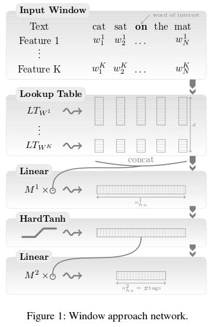

## How to incorporate characters?

- Handcrafted features, limited, undesirable
- Want to take into account most important information into fixed vector for a word
  - Feature extraction with Convolutional Nets
  - Tracks closely with Collobert 2011's Sentence Approach for global coherency!

## Character Level Feature Vector for Words

- Get varying number of chars into fixed representation for a single word
  - First, convert to continuous char representations
  - Next, convolution layer over chars in word
  - Fix width using max over time pooling
- Concatentate with word vector

## Visual Representation of Character Level Embedding Components

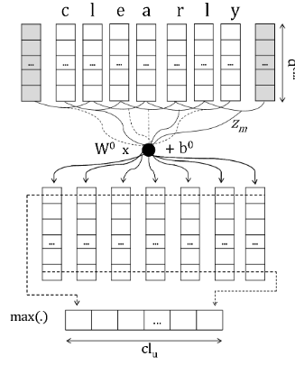

## Full Architecture

- So we have 2 independent representations, char and word level for single word
- For each window, apply Window Approach
  - Concatenate word vector, char word vector
  - Linear layer
  - Non-linearity
  - Output layer produces scores for each tag
- We still have to produce a structured prediction!

## Full Architecture

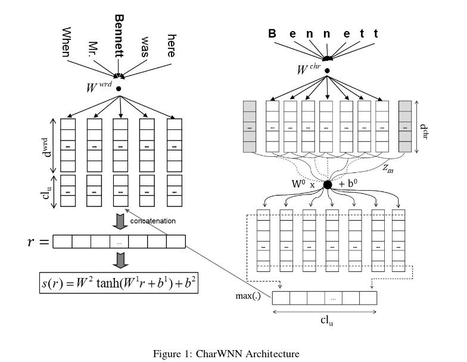

## Structured Prediction Problem

- Could train to minimize word level error, greedily select tags
- Max score for each tag not necessarily coherent
  - Tags have dependencies, Window Approach not globally coherent
- Uses Sentence Log Likelihood cost with transition scores between tags

\[S([w]_{1}^{N}, [t]_{1}^{N}, \theta) = \sum_{n=1}^{N}(A_{t{_n-1},t_n} + s(x_n)t_n)\]

- Viterbi determines selected tag sequence \[[t^*]_{1}^{N} = \arg \max S([w]_{1}^{N}, [t]_{1}^{N}, \theta)\]

## POS Training Details

- Minimize negative log likelihood over training set as in Collobert 2011

\[\log p([t]_{1}^{N} | [w]_{1}^{N}, \theta) = S([w]_{1}^{N}, [t]_{1}^{N}, \theta) - \log( \sum_{\forall [u]_{1}^{N} \in T^n} e^{S([w]_{1}^{N}, [u]_{1}^{N}, \theta)})\]

- SGD used to minimize log-likelihood with respect to \(\theta\)

\[\theta \mapsto \sum_{([w]_{1}^{N}, [y]_{1}^{N}) \in D} -\log p([y]_{1}^{N}|[w]_{1}^{N},\theta)\]

- Learning rate decay \(\lambda_t = \frac{\lambda}{t}\)

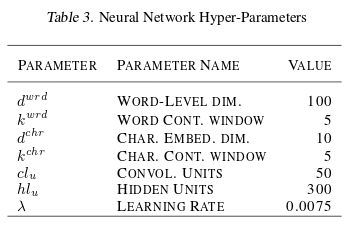

## NER Training Details

- Same (except SPA CoNLL-2002)
- Learning rate set to 0.005 "to avoid divergence"

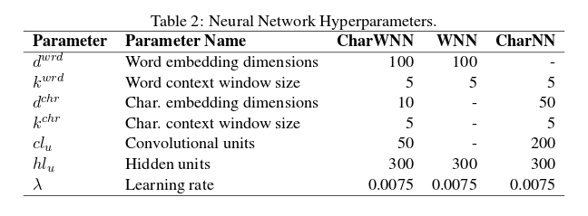

## POS Unsupervised Pre-Training Details

- Word2vec skip-grams used for unsupervised pre-training for word vectors
  - Context window size 5
  - words lower cased
  - English, Wikipedia 12/2013 snapshot, min frequency 10 (870,214 \(|V|\))
  - Portuguese Wikipedia, CETEN Folha Corpus, CETEMPublico corpus, min frequency 5 (453,990 \(|V|\))
- Char embeddings not pre-trained
  - Not lower-cased!
- Custom Portuguese tokenizer

## POS Experiment Details

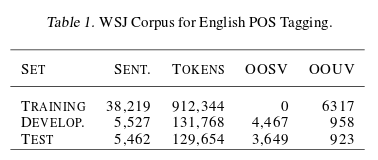

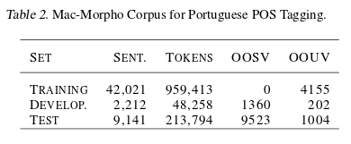

## POS Results (Portuguese)

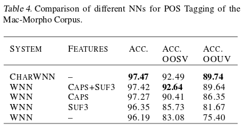

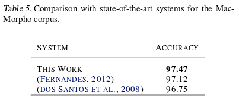

## POS Results (English)

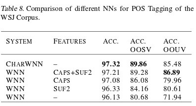

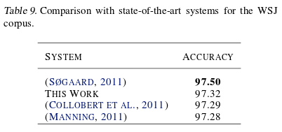

## NER Results (Spanish)

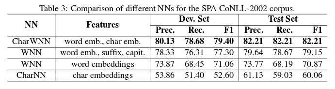

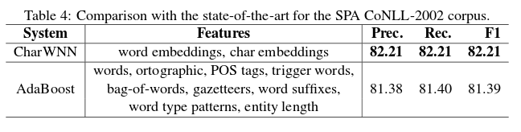

- CoNLL scorer

## NER Results (Portuguese)

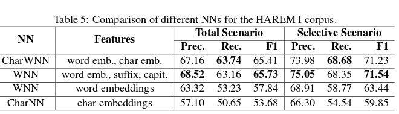

- CoNLL Scorer

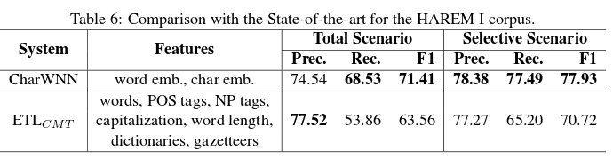

- HAREM I scorer